# 📶 Trilha de Cientista de Dados Jr. - Codigo Certo Coders

Este código foi desenvolvido para realizar a Trilha de Avaliação para a escolha dos Cientistas de Dados Jr. Voluntários do Projeto Codigo Certo Coders. Vale ressaltar que o código abaixo foi escrito em sua totalidade apenas por mim, Ruan Carlos Pontes Caxilé, utilizando como bases para nortear o desenvolvimento do mesmo, materiais de estudo da Cod3r, a Formação em Python da DIO, além de códigos pessoais e consultas realizadas ao ChatGPT e ao Gemini.

```python
"""
Esta célula contém apenas as
importações das bibliotecas que
em algum momento utilizaremos ao
longo deste código fonte e da Trilha.
"""
import pandas as pd # Importando a biblioteca pandas
import matplotlib.pyplot as plt # Importando a biblioteca matplotlib
import seaborn as sns
import os # Importando biblioteca os, para conseguir mexer com pastas e caminhos para arquivos
import mplcursors
from io import StringIO # Importando apenas o StringIO para converter texto em CSV.
```

### 🔋 Carregamento de Dados

De acordo com o que foi pedido nos Requisitos Funcionais, vamos começar com o Carregamento de Dados implementando uma funcionalidade para carregar o conjunto de dados, converter esse Data Set para CSV e por fim salvar na pasta carregamento_de_dados.

```python
"""
Esta célula contém apenas a variável
string_texto_dados_trilha que contém
o texto da Trilha com o conjunto de dados
"""

string_texto_dados_trilha = """ID,Nome do Curso,Quantidade de Vendas,Preço Unitário,Data
                                1,Introdução à Programação em Python,50,39.90,2023-01-01
                                2,Desenvolvimento Web com HTML e CSS,30,59.90,2023-01-02
                                3,JavaScript Avançado: Frameworks e Bibliotecas,20,79.90,2023-01-03
                                4,Introdução ao Machine Learning,15,99.90,2023-01-04
                                5,Desenvolvimento Mobile com React Native,25,69.90,2023-01-05
                                6,Arquitetura de Microserviços,12,89.90,2023-01-06
                                7,Banco de Dados SQL e NoSQL,18,79.90,2023-01-07
                                8,Segurança da Informação: Fundamentos,10,109.90,2023-01-08
                                9,Cloud Computing com AWS,22,99.90,2023-01-09
                                10,DevOps: Integração e Entrega Contínua,8,119.90,2023-01-10
                                11,Desenvolvimento Web com HTML e CSS,20,59.90,2023-01-11
                                12,JavaScript Avançado: Frameworks e Bibliotecas,15,79.90,2023-01-12
                                13,Introdução ao Machine Learning,10,99.90,2023-01-13
                                14,Desenvolvimento Mobile com React Native,18,69.90,2023-01-14
                                15,Arquitetura de Microserviços,8,89.90,2023-01-15
                                16,Banco de Dados SQL e NoSQL,12,79.90,2023-01-16
                                17,Segurança da Informação: Fundamentos,5,109.90,2023-01-17
                                18,Cloud Computing com AWS,15,99.90,2023-01-18
                                19,DevOps: Integração e Entrega Contínua,6,119.90,2023-01-19
                                20,Introdução à Programação em Python,45,39.90,2023-01-20
                                21,Desenvolvimento Web com HTML e CSS,25,59.90,2023-01-21
                                22,JavaScript Avançado: Frameworks e Bibliotecas,18,79.90,2023-01-22
                                23,Introdução ao Machine Learning,12,99.90,2023-01-23
                                24,Desenvolvimento Mobile com React Native,20,69.90,2023-01-24
                                25,Arquitetura de Microserviços,10,89.90,2023-01-25"""
```

```python
"""
Esta célula contém apenas
o processamento com a variável
string_texto_dados_trilha para transformar
em um arquivo CSV a partir do StringIO() e
de um Data Frame, por fim convertendo o Data Frame
para um arquivo CSV e salvando-o na pasta carregamento_de_dados
"""

# Usando StringIO para converter a string em um objeto similar a arquivo
texto_dados_trilha_para_csv = StringIO(string_texto_dados_trilha)

# Lendo a string em um DataFrame
data_frame = pd.read_csv(texto_dados_trilha_para_csv)

# Definindo o caminho da pasta onde o arquivo CSV será salvo
pasta_destino = 'carregamento_de_dados'

# Certifique-se de que a pasta existe, caso contrário, crie-a
os.makedirs(pasta_destino, exist_ok=True)

# Definindo o caminho completo do arquivo CSV
caminho_pasta = os.path.join(pasta_destino, 'vendas_cursos_tech.csv')

# Salvando o DataFrame em um arquivo CSV na pasta especificada
data_frame.to_csv(caminho_pasta, index=False)

print(f"Arquivo CSV criado com sucesso em {caminho_pasta}.")
```

[output not shown]

### 🔍 Exploração de Dados

Após, transformar o texto contendo o conjunto de dados em um arquivo CSV e tendo já um Data Frame salvo na variável data_frame, agora pode ser realizado a Etapa de Exploração de Dados, na qual irei exibir as primeiras linhas e informações básicas do conjunto de dados, como número de linhas, colunas e tipos de dados presentes.

```python
"""
Esta célula irá mostrar
as primeiras linhas do
Data Frame.
"""
# Criando a variável para pegar as 5 primeiras linhas do Data Frame
primeiras_linhas = data_frame.head()

# Exibindo as primeiras linhas, chamando a variável primeiras_linhas
primeiras_linhas
```

|  | ID | Nome do Curso | Quantidade de Vendas | Preço Unitário | Data |
| --- | --- | --- | --- | --- | --- |
| 0 | 1 | Introdução à Programação em Python | 50 | 39.9 | 2023-01-01 |
| 1 | 2 | Desenvolvimento Web com HTML e CSS | 30 | 59.9 | 2023-01-02 |
| 2 | 3 | JavaScript Avançado: Frameworks e Bibliotecas | 20 | 79.9 | 2023-01-03 |
| 3 | 4 | Introdução ao Machine Learning | 15 | 99.9 | 2023-01-04 |
| 4 | 5 | Desenvolvimento Mobile com React Native | 25 | 69.9 | 2023-01-05 |

```python
"""
Esta célula irá mostrar o número de linhas
e o número de colunas.
"""

# Estas variáveis guardam a quantidade de linhas e a quantidade colunas, a partir do atributo shape de um Data Frame, que é uma tupla.
numero_de_linhas, numero_de_colunas = data_frame.shape

print(f"O Data Frame tem {numero_de_linhas} Linhas e {numero_de_colunas} Colunas")
```

```
O Data Frame tem 25 Linhas e 5 Colunas
```

```python
"""
Esta célula irá mostrar os tipos de dados
guardados em cada coluna.
"""

# Esta variável guarda um conjunto de colunas com seus respectivos tipos de dados
tipos_de_dados = data_frame.dtypes


print("Os tipos de dados presentes em cada coluna podem ser observados abaixo:\n", tipos_de_dados)
```

```
Os tipos de dados presentes em cada coluna podem ser observados abaixo:
 ID                        int64
Nome do Curso            object
Quantidade de Vendas      int64
Preço Unitário          float64
Data                     object
dtype: object
```

### 📊 Estatísticas Descritivas

Após a Exploração de Dados, vamos agora calcular e exibir algumas das medidas Estatísticas Descritivas mais comuns, tais como Média, Mediana, Mínimo, Máximo e Desvio Padrão, para cada uma das colunas que possuem valores numéricos e que fazem sentido calcular tais medidas. No caso, seria a coluna de Quantidade de Vendas e a coluna de Preço Unitário.

```python
"""
Esta célula contém todas as
Medidas Estatísticas da Coluna
Quantidade de Vendas
"""

# Variável que guarda a média da quantidade de vendas
media_de_quantidade_de_vendas = data_frame['Quantidade de Vendas'].mean()

#Variável que guarda a mediana da quantidade de vendas
mediana_da_quantidade_de_vendas = data_frame['Quantidade de Vendas'].median()

#Variável que guarda a quantidade mínima de vendas que um curso teve
minimo_quantidade_de_vendas = data_frame['Quantidade de Vendas'].min()

#Variável que guarda a quantidade máxima de vendas que um curso teve
maximo_quantidade_de_vendas = data_frame['Quantidade de Vendas'].max()

#Variável que guarda o desvio padrão da quantidade de vendas
desvio_padrao_quantidade_de_vendas = data_frame['Quantidade de Vendas'].std()

print(f"""Média da Coluna Quantidade de Vendas: {media_de_quantidade_de_vendas:.2f}\n
Mediana da Coluna Quantidade de Vendas: {mediana_da_quantidade_de_vendas:.2f}\n
Quantidade Mínima de Vendas: {minimo_quantidade_de_vendas:.2f}\n
Quantidade Máxima de Vendas: {maximo_quantidade_de_vendas:.2f}\n
Desvio Padrão da Quantidade de Vendas: {desvio_padrao_quantidade_de_vendas:.2f}""")
```

```
Média da Coluna Quantidade de Vendas: 17.96

Mediana da Coluna Quantidade de Vendas: 15.00

Quantidade Mínima de Vendas: 5.00

Quantidade Máxima de Vendas: 50.00

Desvio Padrão da Quantidade de Vendas: 10.92
```

```python
"""
Esta célula contém todas as
Medidas Estatísticas da Coluna
Preço Unitário
"""

# Variável que guarda a média do Preço Unitário
media_de_preco_unitario = data_frame['Preço Unitário'].mean()

#Variável que guarda a mediana do Preço Unitário
mediana_da_preco_unitario = data_frame['Preço Unitário'].median()

#Variável que guarda o preço mínimo de venda que um curso teve
minimo_preco_unitario = data_frame['Preço Unitário'].min()

#Variável que guarda o prçeo máximo de vendaa que um curso teve
maximo_preco_unitario = data_frame['Preço Unitário'].max()

#Variável que guarda o desvio padrão do Preço Unitário
desvio_padrao_preco_unitario = data_frame['Preço Unitário'].std()

print(f"""Média da Coluna Preço Unitário: {media_de_preco_unitario:.2f}\n
Mediana da Coluna Preço Unitário: {mediana_da_preco_unitario:.2f}\n
Preço Mínimo de Venda: {minimo_preco_unitario:.2f}\n
Preço Máximo de Venda: {maximo_preco_unitario:.2f}\n
Desvio Padrão do Preço Unitário: {desvio_padrao_preco_unitario:.2f}""")
```

```
Média da Coluna Preço Unitário: 83.90

Mediana da Coluna Preço Unitário: 79.90

Preço Mínimo de Venda: 39.90

Preço Máximo de Venda: 119.90

Desvio Padrão do Preço Unitário: 21.98
```

### 📉Visualização de Dados

Por fim, a partir do conjunto de dados pode-se gerar Gráficos que trazem Insights de forma visual.

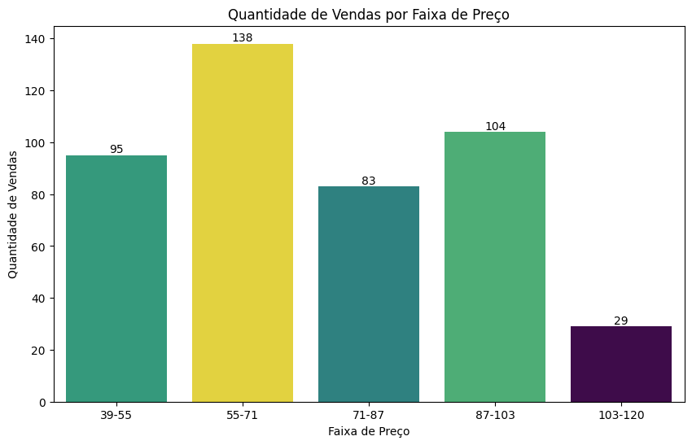

```python
"""
Esta célula é para o Gráfico de Barras
categorizando por faixa de preço e vendo
a relação com a Quantidade vendida.
"""

# Definindo as faixas de preço
limites_de_faixas_de_preco = [39, 55, 71, 87, 103, 120]  # Definindo os limites das faixas de preço
faixas_de_preco = ['39-55', '55-71', '71-87', '87-103', '103-120']  # Definindo os rótulos das faixas de preço

# Criando uma nova coluna no DataFrame para as faixas de preço
data_frame['Faixa de Preço'] = pd.cut(data_frame['Preço Unitário'], bins=limites_de_faixas_de_preco, labels=faixas_de_preco, include_lowest=True)

# Calculando a soma das quantidades vendidas por faixa de preço
faixa_preco_quantidade = data_frame.groupby('Faixa de Preço', observed=True)['Quantidade de Vendas'].sum().reset_index()



# Gráfico de Barras para Quantidade de Vendas por Faixa de Preço
plt.figure(figsize=(10, 6))
ax = sns.barplot(x='Faixa de Preço',hue='Quantidade de Vendas', y='Quantidade de Vendas', data=faixa_preco_quantidade, palette='viridis', legend=False)

# Adicionando Rótulos de Dados para cada Barra presente no gráfico de barras
for container in ax.containers:
    ax.bar_label(container)

# Configurações do Gráfico de Barras
plt.title('Quantidade de Vendas por Faixa de Preço')
plt.xlabel('Faixa de Preço')
plt.ylabel('Quantidade de Vendas')
plt.show()
```

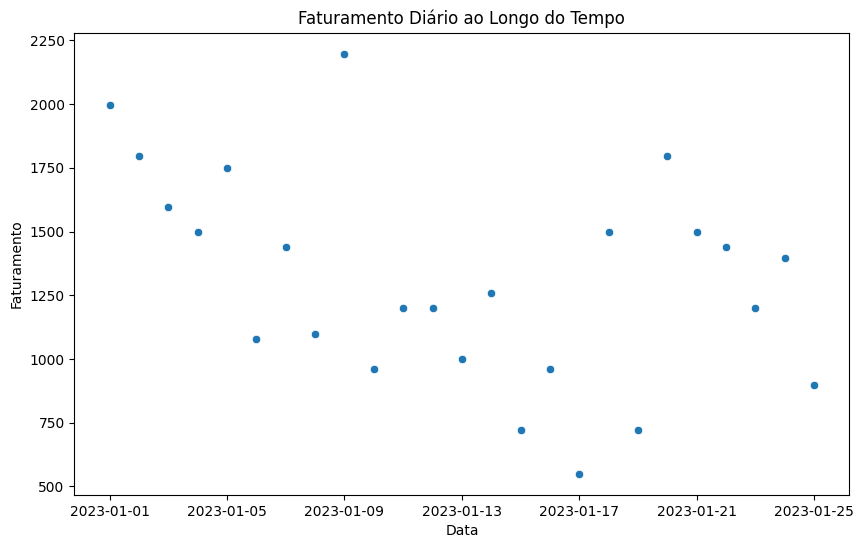

```python
"""
Esta célula é para o Gráfico de Dispersão
do Faturamento Total Diário pelo Tempo
"""
# Converter o tipo de dado da coluna 'Data' para datetime
data_frame['Data'] = pd.to_datetime(data_frame['Data'])

# Calcular o faturamento para cada entrada
data_frame['Faturamento'] = data_frame['Quantidade de Vendas'] * data_frame['Preço Unitário']

# Calcular o faturamento diário total
faturamento_diario = data_frame.groupby('Data')['Faturamento'].sum().reset_index()

# Gráfico de Dispersão faturamento diário total pelo tempo
plt.figure(figsize=(10, 6))
grafico_dispersao = sns.scatterplot(x='Data', y='Faturamento', data=faturamento_diario)
plt.title('Faturamento Diário ao Longo do Tempo')
plt.xlabel('Data')
plt.ylabel('Faturamento')
plt.show()
```

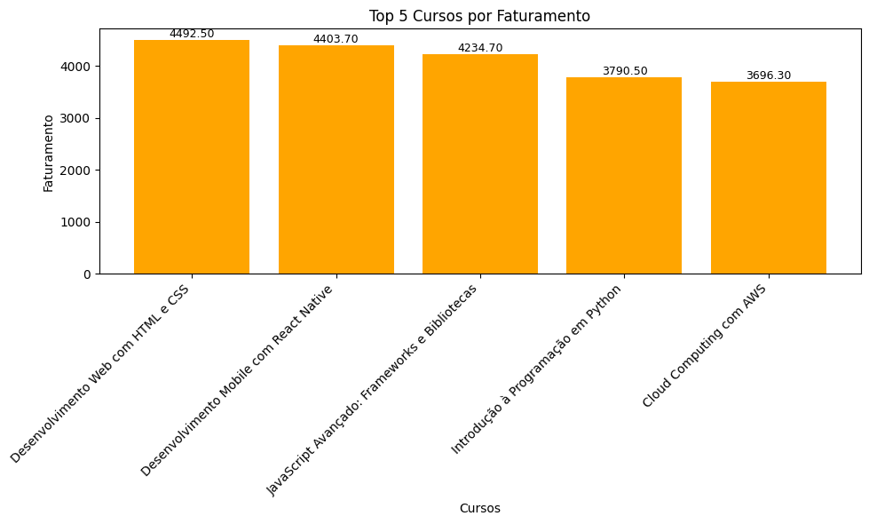

```
O Faturamento Total do Top 5 Cursos com Maiores Faturamentos representa 62.98% do Faturamento Total de R$ 32735.10
```

```python
"""
Esta célula será utilizada
para mostrar o Top 5 dos Cursos
que tem maior faturamento e também
quantos porcentos eles representam
do faturamento total, seguindo a lógica
da Regra de Pareto.
"""

# Cria o data frame para os 5 cursos com maiores faturamentos, agrupando pelo nome do curso e somando todos os faturamentos diários para cada curso
top_5_cursos_com_maiores_faturamentos = data_frame.groupby('Nome do Curso')['Faturamento'].sum().reset_index().sort_values(by='Faturamento', ascending=False).head(5)

# Faturamento Total
faturamento_total = data_frame['Faturamento'].sum()

# Faturamento Total do Top 5 dos Cursos com Maiores Faturamentos
faturamento_total_top_5_cursos_com_maiores_faturamentos = top_5_cursos_com_maiores_faturamentos['Faturamento'].sum()

# Porcentagem que o Top 5 Cursos Com Maiores Faturamentos Representa do Faturamento Total
porcentagem_faturamento_top_5_cursos_com_maiores_faturamentos = 100*(faturamento_total_top_5_cursos_com_maiores_faturamentos/faturamento_total)

# Plotar o gráfico de barras
plt.figure(figsize=(10, 6))
barras_top_5 = plt.bar(top_5_cursos_com_maiores_faturamentos['Nome do Curso'], top_5_cursos_com_maiores_faturamentos['Faturamento'], color='orange')

# Adicionar rótulos de dados (valores) acima das barras
for barra in barras_top_5:
    yval = barra.get_height()
    plt.text(barra.get_x() + barra.get_width()/2, yval, f'{yval:.2f}', ha='center', va='bottom', fontsize=9)


# Configurações do Gráfico
plt.xlabel('Cursos')
plt.ylabel('Faturamento')
plt.title('Top 5 Cursos por Faturamento')
plt.xticks(rotation=45, ha='right')
plt.tight_layout()
plt.show()

print(f"O Faturamento Total do Top 5 Cursos com Maiores Faturamentos representa {porcentagem_faturamento_top_5_cursos_com_maiores_faturamentos:.2f}% do Faturamento Total de R$ {faturamento_total:.2f}")
```

### 🎯Desafios Propostos

Após o fim da visão geral do Conjunto de Dados passando pelo Carregamento de Dados, a Exploração de Dados , as Estatísticas Descritivas e a Visualização de Dados, agora irá ser resolvido os Desafios Propostos na Trilha, os quais são:

1. Calcular a receita total gerada pela venda dos cursos.
2. Identificar o curso com o maior número de vendas.
3. Visualizar a distribuição das vendas ao longo do tempo através de gráficos.

```python
"""
Esta célula irá conter
a resolução do Desafio Proposto 1
"""

# O processo de Resolução do Desafio Proposto 1 já foi realizado e o resultado está guardado na Variável faturamento_total

print(f"A Receita Total gerada pela venda dos cursos foi de R$ {faturamento_total:.2f}")
```

```
A Receita Total gerada pela venda dos cursos foi de R$ 32735.10
```

```python
"""
Esta célular irá conter
a resolução do Desafio Proposto 2
"""

# Criando o Data Frame que contém apenas o Curso Mais Vendido com seu nome e a Quantidade de Vendas.
curso_mais_vendido = data_frame.groupby('Nome do Curso')['Quantidade de Vendas'].sum().reset_index().sort_values(by='Quantidade de Vendas', ascending=False).head(1)

# Chamando a variável curso_mais_vendido para saber o curso mais vendido
curso_mais_vendido
```

|  | Nome do Curso | Quantidade de Vendas |
| --- | --- | --- |
| 7 | Introdução à Programação em Python | 95 |

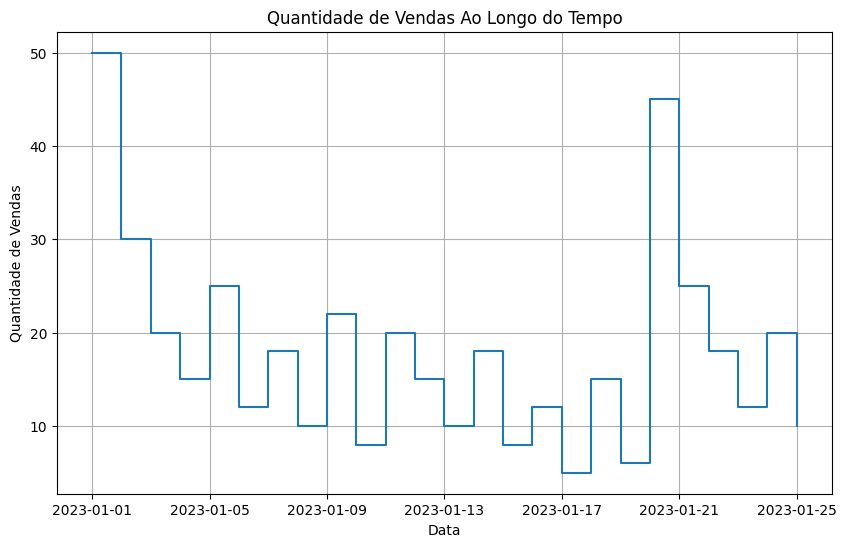

```python
"""
Esta célular irá conter
a resolução do Desafio Proposto 3
"""

# Plotar o Gráfico de Degrau da Quantidade de Vendas pelo Tempo
plt.figure(figsize=(10, 6))
sns.lineplot(data=data_frame, x='Data', y='Quantidade de Vendas', drawstyle='steps-post')
plt.title('Quantidade de Vendas Ao Longo do Tempo')
plt.xlabel('Data')
plt.ylabel('Quantidade de Vendas')
plt.grid(True)
plt.show()
```